# IE 582 HW 3

Mehmet Atilla Purazer

28 11 2019

```r
# IMPORTING DATA and INVESTIGATING DATA
require(dplyr)
require(data.table)
require(stringr)
```

```r
require(ggplot2)
require(lubridate)
require(penalized)
require(arules)
require(glmnet)
#require(ie2misc)
#require(tidyverse)
```

#Train data IMPORTING Train DATA and INVESTIGATING DATA and PREPARING DATA FOR STUDY Data is visually inspected. The date 27 March 2016 is missing Assumption: The data of 20 March 2016 (same day one week before) is assumed to be same as the data of 27 March 2016. therefore copied to the missing date

```r
Data_20160101_20191101<- read.table("C:\\Users\\MEHMET\\Desktop\\IE 582 HW3\\GercekZamanliTuketim-01012016-01112019.csv",header = T)
Data_20160101_20191101 = Data_20160101_20191101[,-3]
Data_20160101_20191101 = Data_20160101_20191101[,-4]

head(Data_20160101_20191101)
```

```
##        Tarih.  Saat Tüketim.Miktarı..MWh.
## 1 01.01.2016, 00:00             26.277,24
## 2 01.01.2016, 01:00             24.991,82
## 3 01.01.2016, 02:00             23.532,61
## 4 01.01.2016, 03:00             22.464,78
## 5 01.01.2016, 04:00             22.002,91
## 6 01.01.2016, 05:00             21.957,08
```

```r
str(Data_20160101_20191101)
```

```
## 'data.frame':    33624 obs. of  3 variables:
##  $ Tarih.               : Factor w/ 1401 levels "01.01.2016,",..: 1 1 1 1 1 1 1 1 1 1 ...
##  $ Saat                 : Factor w/ 24 levels "00:00","01:00",..: 1 2 3 4 5 6 7 8 9 10 ...
##  $ Tüketim.Miktarı..MWh.: Factor w/ 33252 levels "17.796,48","17.940,44",..: 3433 1705 678 291 211 204 239 187 494 1938 ...
```

```r
summary(Data_20160101_20191101)
```

```
##          Tarih.           Saat       Tüketim.Miktarı..MWh.
##  01.01.2016,:   24   00:00  : 1401   27.340,44:    3
##  01.01.2017,:   24   01:00  : 1401   31.913,39:    3
##  01.01.2018,:   24   02:00  : 1401   33.825,89:    3
##  01.01.2019,:   24   03:00  : 1401   22.171,60:    2
##  01.02.2016,:   24   04:00  : 1401   22.361,72:    2
##  01.02.2017,:   24   05:00  : 1401   22.738,71:    2
##  (Other)    :33480   (Other):25218   (Other)  :33609
```

```r
Data_20160101_20191101$Tarih<-as.Date(Data_20160101_20191101$Tarih,"%d.%m.%Y")

Data_20160101_20191101["TarihSaat"] <- NA
Data_20160101_20191101$TarihSaat <- paste0(Data_20160101_20191101$Tarih," ",Data_20160101_20191101$Saat)

Data_20160101_20191101["gün"] <- NA
Data_20160101_20191101$gun <-substring(Data_20160101_20191101$Tarih., 1, 2)
Data_20160101_20191101["ay"] <- NA
Data_20160101_20191101$ay <-substring(Data_20160101_20191101$Tarih., 4, 5)
Data_20160101_20191101["yıl"] <- NA
Data_20160101_20191101$yil <-substring(Data_20160101_20191101$Tarih., 7, 10)

Data_20160101_20191101["YILay"] <- NA
Data_20160101_20191101$YILay <-substring(Data_20160101_20191101$Tarih., 4, 10)
colnames(Data_20160101_20191101)[colnames(Data_20160101_20191101)=="Tüketim.Miktarı..MWh."] <- "MWh"
Data_20160101_20191101$MWh = gsub("[.]", "",Data_20160101_20191101$MWh)
Data_20160101_20191101$MWh = gsub("[,]", ".",Data_20160101_20191101$MWh)
Data_20160101_20191101$MWh = as.numeric(Data_20160101_20191101$MWh)
head(Data_20160101_20191101)
```

```
##        Tarih.  Saat      MWh      Tarih        TarihSaat gün gun ay yıl
## 1 01.01.2016, 00:00 26277.24 2016-01-01 2016-01-01 00:00  NA  01 01  NA
## 2 01.01.2016, 01:00 24991.82 2016-01-01 2016-01-01 01:00  NA  01 01  NA
## 3 01.01.2016, 02:00 23532.61 2016-01-01 2016-01-01 02:00  NA  01 01  NA
## 4 01.01.2016, 03:00 22464.78 2016-01-01 2016-01-01 03:00  NA  01 01  NA
## 5 01.01.2016, 04:00 22002.91 2016-01-01 2016-01-01 04:00  NA  01 01  NA
## 6 01.01.2016, 05:00 21957.08 2016-01-01 2016-01-01 05:00  NA  01 01  NA
##    yil   YILay
## 1 2016 01.2016
## 2 2016 01.2016
## 3 2016 01.2016
## 4 2016 01.2016
## 5 2016 01.2016
## 6 2016 01.2016
```

```r
str(Data_20160101_20191101)
```

```
## 'data.frame':    33624 obs. of  11 variables:
##  $ Tarih.   : Factor w/ 1401 levels "01.01.2016,",..: 1 1 1 1 1 1 1 1 1 1 ...
##  $ Saat     : Factor w/ 24 levels "00:00","01:00",..: 1 2 3 4 5 6 7 8 9 10 ...
##  $ MWh      : num  26277 24992 23533 22465 22003 ...
##  $ Tarih    : Date, format: "2016-01-01" "2016-01-01" ...
##  $ TarihSaat: chr  "2016-01-01 00:00" "2016-01-01 01:00" "2016-01-01 02:00" "2016-01-01 03:00" ...
##  $ gün      : logi  NA NA NA NA NA NA ...
##  $ gun      : chr  "01" "01" "01" "01" ...
##  $ ay       : chr  "01" "01" "01" "01" ...
##  $ yıl      : logi  NA NA NA NA NA NA ...
##  $ yil      : chr  "2016" "2016" "2016" "2016" ...
##  $ YILay    : chr  "01.2016" "01.2016" "01.2016" "01.2016" ...
```

```r
Data_20160101_20191101 = data.table(Data_20160101_20191101)
```

Elektrik tüketiminin gunün saatine göre değişimi ve yillara göre karşılaştırması

```r
grafik_saat  <-  ggplot(data=Data_20160101_20191101, aes(x =Tarih, y = MWh)) + geom_point(aes(colour = Saat)) + labs( title = "Tüketim Miktarı (MWh)", legend = "Saat")
#grafik_saat
```

```r
grafik_gun  <-  ggplot(data=Data_20160101_20191101, aes(x =Tarih, y = MWh)) + geom_point(aes(colour = gun)) + labs( title = "Tüketim Miktarı (MWh)", legend = "gun")
#grafik_gun
```

```r
grafik_ay  <-  ggplot(data=Data_20160101_20191101, aes(x =Tarih, y = MWh)) + geom_point(aes(colour = ay)) + labs( title = "Tüketim Miktarı (MWh)", legend = "ay")
#grafik_ay
```

```r
gunluk_tuketim = Data_20160101_20191101[,.(MWh = sum(MWh)),.(Tarih) ]
grafik_gunluk_tuketim <- ggplot(data = gunluk_tuketim, aes(x =Tarih, y =MWh)) +geom_line(aes(colour = "red")) +labs( title = "gunluk elektrik tuketimi", legend = "gun") +geom_smooth(method = "lm")
#grafik_gunluk_tuketim
```

#TASK A

168 and 48 hours ago consumption values as your naïve approaches to predict next day’s consumption. Assume that you are willing to use 168 and 48 hours ago consumption values as your naïve approaches to predict next day’s consumption. Assume that the test period includes the dates after 1st of November, 2019 (included). For both approaches, report the summary statistics of MAPE values for the test period.

```r
Data_20160101_20191101 <- Data_20160101_20191101[order(Data_20160101_20191101[,Data_20160101_20191101$TarihSaat])]
```

#Test data Loading Test data IMPORTING Train DATA and INVESTIGATING DATA and PREPARING DATA FOR STUDY

```r
Test_Data_20191101_20191123<- read.table("C:\\Users\\MEHMET\\Desktop/IE 582 HW3\\TEST_Data_GercekZamanliTuketim-01112019-23112019.csv",header = T)
Test_Data_20191101_20191123 = Test_Data_20191101_20191123 [,-3]
Test_Data_20191101_20191123 = Test_Data_20191101_20191123 [,-4]

Test_Data_20191101_20191123 = Test_Data_20191101_20191123[-(529:552),]

Test_Data_20191101_20191123$Tarih<-as.Date(Test_Data_20191101_20191123$Tarih,"%d.%m.%Y")
str(Test_Data_20191101_20191123)
```

```
## 'data.frame':    528 obs. of  4 variables:
##  $ Tarih.               : Factor w/ 23 levels "01.11.2019,",..: 1 1 1 1 1 1 1 1 1 1 ...
##  $ Saat                 : Factor w/ 24 levels "00:00","01:00",..: 1 2 3 4 5 6 7 8 9 10 ...
##  $ Tüketim.Miktarı..MWh.: Factor w/ 531 levels "0,00","126,90",..: 177 133 87 67 61 73 118 173 293 393 ...
##  $ Tarih                : Date, format: "2019-11-01" "2019-11-01" ...
```

```r
Test_Data_20191101_20191123["TarihSaat"] <- NA
Test_Data_20191101_20191123$TarihSaat <- paste0(Test_Data_20191101_20191123$Tarih," ", Test_Data_20191101_20191123$Saat)

Test_Data_20191101_20191123 ["gun"] <- NA
Test_Data_20191101_20191123$gun <-substring(Test_Data_20191101_20191123$Tarih, 9, 10)
Test_Data_20191101_20191123 ["ay"] <- NA
Test_Data_20191101_20191123$ay <-substring(Test_Data_20191101_20191123$Tarih, 6, 7)
Test_Data_20191101_20191123 ["yil"] <- NA
Test_Data_20191101_20191123$yil <-substring(Test_Data_20191101_20191123$Tarih, 1, 4)

Test_Data_20191101_20191123["YILay"] <- NA
Test_Data_20191101_20191123$YILay <-substring(Test_Data_20191101_20191123$Tarih, 1, 7)
colnames(Test_Data_20191101_20191123)[colnames(Test_Data_20191101_20191123)=="Tüketim.Miktarı..MWh."] <- "MWh"
Test_Data_20191101_20191123$MWh = gsub("[.]","",Test_Data_20191101_20191123$MWh)
Test_Data_20191101_20191123$MWh = gsub("[,]", ".",Test_Data_20191101_20191123$MWh)


Test_Data_20191101_20191123$MWh =as.numeric(Test_Data_20191101_20191123$MWh)


head(Test_Data_20191101_20191123)
```

```
##        Tarih.  Saat      MWh      Tarih        TarihSaat gun ay  yil
## 1 01.11.2019, 00:00 29417.56 2019-11-01 2019-11-01 00:00  01 11 2019
## 2 01.11.2019, 01:00 28133.75 2019-11-01 2019-11-01 01:00  01 11 2019
## 3 01.11.2019, 02:00 27358.60 2019-11-01 2019-11-01 02:00  01 11 2019
## 4 01.11.2019, 03:00 26780.09 2019-11-01 2019-11-01 03:00  01 11 2019
## 5 01.11.2019, 04:00 26511.54 2019-11-01 2019-11-01 04:00  01 11 2019
## 6 01.11.2019, 05:00 27002.74 2019-11-01 2019-11-01 05:00  01 11 2019
##     YILay
## 1 2019-11
## 2 2019-11
## 3 2019-11
## 4 2019-11
## 5 2019-11
## 6 2019-11
```

```r
str(Test_Data_20191101_20191123)
```

```
## 'data.frame':    528 obs. of  9 variables:
##  $ Tarih.   : Factor w/ 23 levels "01.11.2019,",..: 1 1 1 1 1 1 1 1 1 1 ...
##  $ Saat     : Factor w/ 24 levels "00:00","01:00",..: 1 2 3 4 5 6 7 8 9 10 ...
##  $ MWh      : num  29418 28134 27359 26780 26512 ...
##  $ Tarih    : Date, format: "2019-11-01" "2019-11-01" ...
##  $ TarihSaat: chr  "2019-11-01 00:00" "2019-11-01 01:00" "2019-11-01 02:00" "2019-11-01 03:00" ...
##  $ gun      : chr  "01" "01" "01" "01" ...
##  $ ay       : chr  "11" "11" "11" "11" ...
##  $ yil      : chr  "2019" "2019" "2019" "2019" ...
##  $ YILay    : chr  "2019-11" "2019-11" "2019-11" "2019-11" ...
```

```r
Test_Data_20191101_20191123= data.table(Test_Data_20191101_20191123)

Data_20160101_20191101 <- Data_20160101_20191101[order(Data_20160101_20191101[,Data_20160101_20191101$TarihSaat])]

#parse_date_time(Data_20160101_20191101$TarihSaat, orders ="ymd HM")

Data_20160101_20191101$TarihSaat =parse_date_time(Data_20160101_20191101$TarihSaat, orders ="ymd HM")


Data_20160101_20191101[, Lag_168_Time := (TarihSaat - 7*24*60*60)]
Data_20160101_20191101[, Lag_168 := shift(MWh,168, type = "lag")]

Data_20160101_20191101[, Lag_48_Time := (TarihSaat - 2*24*60*60)]
Data_20160101_20191101[, Lag_48 := shift(MWh,48, type = "lag")]
train <- Data_20160101_20191101[!is.na(Lag_168) ]
tail(train)
```

```
##         Tarih.  Saat      MWh      Tarih           TarihSaat gün gun ay
## 1: 01.11.2019, 18:00 37199.91 2019-11-01 2019-11-01 18:00:00  NA  01 11
## 2: 01.11.2019, 19:00 36056.96 2019-11-01 2019-11-01 19:00:00  NA  01 11
## 3: 01.11.2019, 20:00 35130.19 2019-11-01 2019-11-01 20:00:00  NA  01 11
## 4: 01.11.2019, 21:00 33947.64 2019-11-01 2019-11-01 21:00:00  NA  01 11
## 5: 01.11.2019, 22:00 32877.69 2019-11-01 2019-11-01 22:00:00  NA  01 11
## 6: 01.11.2019, 23:00 31590.75 2019-11-01 2019-11-01 23:00:00  NA  01 11
##    yıl  yil   YILay        Lag_168_Time  Lag_168         Lag_48_Time
## 1:  NA 2019 11.2019 2019-10-25 18:00:00 36302.11 2019-10-30 18:00:00
## 2:  NA 2019 11.2019 2019-10-25 19:00:00 35698.70 2019-10-30 19:00:00
## 3:  NA 2019 11.2019 2019-10-25 20:00:00 34820.93 2019-10-30 20:00:00
## 4:  NA 2019 11.2019 2019-10-25 21:00:00 33659.48 2019-10-30 21:00:00
## 5:  NA 2019 11.2019 2019-10-25 22:00:00 32696.81 2019-10-30 22:00:00
## 6:  NA 2019 11.2019 2019-10-25 23:00:00 30942.64 2019-10-30 23:00:00
##      Lag_48
## 1: 36936.24
## 2: 36219.71
## 3: 35136.55
## 4: 34155.15
## 5: 32878.23
## 6: 31456.46
```

```r
nrow(train)
```

```
## [1] 33456
```

```r
Test_Data_20191101_20191123 <- Test_Data_20191101_20191123[order(Test_Data_20191101_20191123[,Test_Data_20191101_20191123$TarihSaat])]
#parse_date_time(Test_Data_20191101_20191123$TarihSaat, orders ="ymd HM")
Test_Data_20191101_20191123$TarihSaat =parse_date_time(Test_Data_20191101_20191123$TarihSaat, orders ="ymd HM")

Test_Data_20191101_20191123[, Lag_168_Time := (TarihSaat - 7*24*60*60)]
Test_Data_20191101_20191123[, Lag_168 := shift(MWh,168, type = "lag")]

Test_Data_20191101_20191123[, Lag_48_Time := (TarihSaat - 2*24*60*60)]
Test_Data_20191101_20191123[, Lag_48 := shift(MWh,48, type = "lag")]

test <- Test_Data_20191101_20191123
tail(test)
```

```
##         Tarih.  Saat      MWh      Tarih           TarihSaat gun ay  yil
## 1: 22.11.2019, 18:00 38326.87 2019-11-22 2019-11-22 18:00:00  22 11 2019
## 2: 22.11.2019, 19:00 37185.01 2019-11-22 2019-11-22 19:00:00  22 11 2019
## 3: 22.11.2019, 20:00 36343.47 2019-11-22 2019-11-22 20:00:00  22 11 2019
## 4: 22.11.2019, 21:00 34917.32 2019-11-22 2019-11-22 21:00:00  22 11 2019
## 5: 22.11.2019, 22:00 31602.03 2019-11-22 2019-11-22 22:00:00  22 11 2019
## 6: 22.11.2019, 23:00   621.60 2019-11-22 2019-11-22 23:00:00  22 11 2019
##      YILay        Lag_168_Time  Lag_168         Lag_48_Time   Lag_48
## 1: 2019-11 2019-11-15 18:00:00 37339.89 2019-11-20 18:00:00 38627.93
## 2: 2019-11 2019-11-15 19:00:00 36414.05 2019-11-20 19:00:00 37509.10
## 3: 2019-11 2019-11-15 20:00:00 35575.32 2019-11-20 20:00:00 36750.73
## 4: 2019-11 2019-11-15 21:00:00 34676.26 2019-11-20 21:00:00 35795.20
## 5: 2019-11 2019-11-15 22:00:00 33863.58 2019-11-20 22:00:00 35086.50
## 6: 2019-11 2019-11-15 23:00:00 32559.88 2019-11-20 23:00:00 33296.62
```

```r
nrow(test)
```

```
## [1] 528
```

```r
#replacing NA values with 28000
Test_Data_20191101_20191123[is.na(Test_Data_20191101_20191123)] <-28000
Data_20160101_20191101[is.na(Data_20160101_20191101)] <-28000
```

Calculate the (percentage/squared) errors for every entry: pred_error <- real - predicted pct_error <- pred_error/real squared_error <- pred_error^2 Calculate MSE, MAPE:

apply(squared_error, MARGIN = 1, mean) # MSE apply(abs(pct_error), MARGIN = 1, mean) # MAPE

#LAG 48 MAPE Training Period

```r
Data_20160101_20191101$pred_error_training_lag48   <- Data_20160101_20191101$MWh - Data_20160101_20191101$ Lag_48
Data_20160101_20191101$pct_error_training_lag48    <-  Data_20160101_20191101$pred_error_training_lag48 /Data_20160101_20191101$MWh
Data_20160101_20191101$squared_error_training_lag48 <- Data_20160101_20191101$pct_error_training_lag48^2
Data_20160101_20191101 = data.table(Data_20160101_20191101)

MSE  <- mean(Data_20160101_20191101$squared_error_training_lag48)

MAPE  <-mean(abs(Data_20160101_20191101$pct_error_training_lag48))
MAPE
```

```
## [1] 0.07920353
```

#LAG 168 MAPE Training Period

```r
Data_20160101_20191101$pred_error_training_lag168   <- Data_20160101_20191101$MWh - Data_20160101_20191101$ Lag_168
Data_20160101_20191101$pct_error_training_lag168    <-  Data_20160101_20191101$pred_error_training_lag168 /Data_20160101_20191101$MWh
Data_20160101_20191101$squared_error_training_lag168 <- Data_20160101_20191101$pct_error_training_lag168^2
Data_20160101_20191101 = data.table(Data_20160101_20191101)


MSE  <- mean(Data_20160101_20191101$squared_error_training_lag168)

MAPE  <-mean(abs(Data_20160101_20191101$pct_error_training_lag168))
MAPE
```

```
## [1] 0.05036626
```

#LAG 48 MAPE Test Period

```r
Test_Data_20191101_20191123$pred_error_test_lag48   <- Test_Data_20191101_20191123$MWh - Test_Data_20191101_20191123$ Lag_48
Test_Data_20191101_20191123$pct_error_test_lag48    <-  Test_Data_20191101_20191123$pred_error_test_lag48/Test_Data_20191101_20191123$MWh

Test_Data_20191101_20191123$squared_error_test_lag48 <- Test_Data_20191101_20191123$pct_error_test_lag48^2

#Test_Data_20191101_20191123$pct_error_test_lag48[-(531:552)]
Test_Data_20191101_20191123 = data.table(Test_Data_20191101_20191123)

#Test_Data_20191101_20191123 =Test_Data_20191101_20191123[-(530:552),]

#MSE  <- apply(Test_Data_20191101_20191123$squared_error_test_lag48, 1, mean)
MSE  <- mean(Test_Data_20191101_20191123$squared_error_test_lag48)
#MAPE  <-apply(abs(Test_Data_20191101_20191123$pct_error_test_lag48), MARGIN = 1, mean)
MAPE  <-mean(abs(Test_Data_20191101_20191123$pct_error_test_lag48))
MAPE
```

```
## [1] 0.1811528
```

#LAG 168 MAPE Test Period

```r
Test_Data_20191101_20191123$pred_error_test_lag168   <- Test_Data_20191101_20191123$MWh - Test_Data_20191101_20191123$ Lag_168

Test_Data_20191101_20191123$pct_error_test_lag168    <-  Test_Data_20191101_20191123$pred_error_test_lag168/Test_Data_20191101_20191123$MWh

Test_Data_20191101_20191123$squared_error_test_lag168 <- Test_Data_20191101_20191123$pct_error_test_lag168^2

#Test_Data_20191101_20191123$pct_error_test_lag168[-(531:552)]
Test_Data_20191101_20191123 = data.table(Test_Data_20191101_20191123)

#Test_Data_20191101_20191123 =Test_Data_20191101_20191123[-(530:552),]

#MSE  <- apply(Test_Data_20191101_20191123$squared_error_test_lag168, 1, mean)
MSE  <- mean(Test_Data_20191101_20191123$squared_error_test_lag168)
#MAPE  <-apply(abs(Test_Data_20191101_20191123$pct_error_test_lag168), MARGIN = 1, mean)
MAPE  <-mean(abs(Test_Data_20191101_20191123$pct_error_test_lag168))
MAPE
```

```
## [1] 0.1491463
```

```r
Mapevalue_part_A <- c(0.1491566)
```

#CONCLUSION OF TASK A

AS EXPECTED in lag48 and lag168 cases Test Error is greater than training error

When we compare lag48 and lag168 cases Error rates in lag 168 is smaller than lag 48 case

training and test results are consistent for both lag 48 and lag 168

#TASK B build a linear regression model

# MODEL will be as follows : consumption=beta(0)+beta(1)xlag48+beta(2)xlag168

```r
Training_Data_Lin_Reg <- Data_20160101_20191101

Lin_Reg <- lm(MWh ~ Lag_48 + Lag_168, data= Training_Data_Lin_Reg )
summary(Lin_Reg)
```

```
##
## Call:
## lm(formula = MWh ~ Lag_48 + Lag_168, data = Training_Data_Lin_Reg)
##
## Residuals:
##    Min     1Q Median     3Q    Max
## -16786  -1006     -6   1024  15919
##
## Coefficients:
##              Estimate Std. Error t value Pr(>|t|)
## (Intercept) 1.647e+03  9.681e+01   17.02   <2e-16 ***
## Lag_48      3.279e-01  3.520e-03   93.14   <2e-16 ***
## Lag_168     6.220e-01  3.521e-03  176.62   <2e-16 ***
## ---
## Signif. codes:  0 '***' 0.001 '**' 0.01 '*' 0.05 '.' 0.1 ' ' 1
##
## Residual standard error: 2413 on 33621 degrees of freedom
## Multiple R-squared:  0.7608, Adjusted R-squared:  0.7608
## F-statistic: 5.348e+04 on 2 and 33621 DF,  p-value: < 2.2e-16
```

The results show that all (ie intercept, beta(1), beta(2)) are significant

MWh = 1.647e+03 + 3.279e-01 * Lag_48 + 6.220e-01 * Lag_168

```r
Training_Data_Lin_Reg$Prediction_Lin_Reg <- 1647 + 0.3279 * Training_Data_Lin_Reg$Lag_48 + 0.6220 * Training_Data_Lin_Reg$Lag_168
Training_Data_Lin_Reg <-data.frame(Training_Data_Lin_Reg)
```

# Lin Reg MAPE Training Period

```r
Training_Data_Lin_Reg$pred_error_Lin_Reg   <- Training_Data_Lin_Reg$MWh - Training_Data_Lin_Reg$Prediction_Lin_Reg
Training_Data_Lin_Reg$pred_error_Lin_Reg <-  Training_Data_Lin_Reg$pred_error_Lin_Reg   / Training_Data_Lin_Reg$MWh
Training_Data_Lin_Reg$squared_error_training_Lin_Reg <- Training_Data_Lin_Reg$pred_error_Lin_Reg ^2

MSE  <- mean(Training_Data_Lin_Reg$squared_error_training_Lin_Reg)

MAPE  <-mean(abs(Training_Data_Lin_Reg$pred_error_Lin_Reg))
MAPE
```

```
## [1] 0.04976722
```

# Lin Reg MAPE Test Period

```r
Test_Data_Lin_Reg <- Test_Data_20191101_20191123

Test_Data_Lin_Reg$Prediction_Lin_Reg <- 1647 + 0.3279 * Test_Data_Lin_Reg$Lag_48 + 0.6220 * Test_Data_Lin_Reg$Lag_168
#plot(Lin_Reg)
Test_Data_Lin_Reg <-data.frame(Test_Data_Lin_Reg)

colnames(Test_Data_Lin_Reg)[colnames(Test_Data_Lin_Reg)=="Tuketim.Miktarı..MWh."] <- "MWh"

Test_Data_20191101_20191123$MWh= gsub("[.]", "",Test_Data_20191101_20191123$MWh)
Test_Data_20191101_20191123$MWh = gsub("[,]", ".",Test_Data_20191101_20191123$MWh)
Test_Data_20191101_20191123$MWh =as.numeric(Test_Data_20191101_20191123$MW)

Test_Data_Lin_Reg$pred_error_Lin_Reg   <- Test_Data_Lin_Reg$MWh - Test_Data_Lin_Reg$Prediction_Lin_Reg
Test_Data_Lin_Reg$pred_error_Lin_Reg <-  Test_Data_Lin_Reg$pred_error_Lin_Reg   / Test_Data_Lin_Reg$MWh
Test_Data_Lin_Reg$squared_error_training_Lin_Reg <- Test_Data_Lin_Reg$pred_error_Lin_Reg ^2
#Data_20160101_20191101 = data.table(Data_20160101_20191101)

MSE  <- mean(Test_Data_Lin_Reg$squared_error_training_Lin_Reg)

MAPE  <-mean(abs(Test_Data_Lin_Reg$pred_error_Lin_Reg))
MAPE
```

```
## [1] 0.1550333
```

```r
Mapevalue_part_B <- c(0.1550613)
```

#CONCLUSION OF TASK B

AS EXPECTED in Linear Regression Test Error is greater than training error

#TASK C modeling each hour separately

As mentioned earlier, hourly seasonality is important. Although we used the same hour’s consumption value of the past days to handle this problem for part (b), we implicitly impose an assumption that prediction model for each hour has the same coefficients which may not be correct since the consumption behavior at nights can be different than the other hours. Therefore, modeling each hour separately is another way to approach to the same problem. Train linear regression models for each hour using the # same training period (24 models) and report your test performance as in part (a).

24 different models one model for each hour of the day

to divide Training data in to 24 sub data

```r
Train_data_main <- split(Data_20160101_20191101, Data_20160101_20191101$Saat)
Train_hour_0 <- Train_data_main$`00:00`
Train_hour_1 <- Train_data_main$`01:00`
Train_hour_2 <- Train_data_main$`02:00`
Train_hour_3 <- Train_data_main$`03:00`
Train_hour_4 <- Train_data_main$`04:00`
Train_hour_5 <- Train_data_main$`05:00`
Train_hour_6 <- Train_data_main$`06:00`
Train_hour_7 <- Train_data_main$`07:00`
Train_hour_8 <- Train_data_main$`08:00`
Train_hour_9 <- Train_data_main$`09:00`
Train_hour_10 <- Train_data_main$`10:00`
Train_hour_11 <- Train_data_main$`11:00`
Train_hour_12 <- Train_data_main$`12:00`
Train_hour_13 <- Train_data_main$`13:00`
Train_hour_14 <- Train_data_main$`14:00`
Train_hour_15 <- Train_data_main$`15:00`
Train_hour_16 <- Train_data_main$`16:00`
Train_hour_17 <- Train_data_main$`17:00`
Train_hour_18 <- Train_data_main$`18:00`
Train_hour_19 <- Train_data_main$`19:00`
Train_hour_20 <- Train_data_main$`20:00`
Train_hour_21 <- Train_data_main$`21:00`
Train_hour_22 <- Train_data_main$`22:00`
Train_hour_23 <- Train_data_main$`23:00`

Lin_Reg_hr_0 <- lm(MWh ~ Lag_48 + Lag_168, data= Train_hour_0)
summary(Lin_Reg_hr_0)
```

```
##
## Call:
## lm(formula = MWh ~ Lag_48 + Lag_168, data = Train_hour_0)
##
## Residuals:
##     Min      1Q  Median      3Q     Max
## -9085.8  -772.1    41.3   869.5  6267.2
##
## Coefficients:
##              Estimate Std. Error t value Pr(>|t|)
## (Intercept) 2.385e+03  5.041e+02   4.731 2.46e-06 ***
## Lag_48      5.018e-01  1.904e-02  26.349  < 2e-16 ***
## Lag_168     4.212e-01  1.906e-02  22.097  < 2e-16 ***
## ---
## Signif. codes:  0 '***' 0.001 '**' 0.01 '*' 0.05 '.' 0.1 ' ' 1
##
## Residual standard error: 1601 on 1398 degrees of freedom
## Multiple R-squared:  0.6987, Adjusted R-squared:  0.6983
## F-statistic:  1621 on 2 and 1398 DF,  p-value: < 2.2e-16
```

The results show that all (ie intercept, beta(1), beta(2)) are significant

MWh = 2.385e+03 + 5.018e-01 * Lag_48 + 4.212e-01 * Lag_168

The same task is repeated for 23 times and the results are as follows In all cases beta’s are significant

The models for each hour are follows hour 00:00 Reg line

Train_hour_0$Prediction_Lin_Reg <- 2385 + 0.5018 * Train_hour_0$Lag_48 + 0.4212 * Train_hour_0$Lag_168 Train_hour_1$Prediction_Lin_Reg <- 2271 + 0.5070 * Train_hour_2$Lag_48 + 0.4156 * Train_hour_1$Lag_168 Train_hour_2$Prediction_Lin_Reg <- 2238 + 0.5097* Train_hour_3$Lag_48 + 0.4074 * Train_hour_2$Lag_168 Train_hour_3$Prediction_Lin_Reg <- 2403 + 0.5030* Train_hour_3$Lag_48 + 0.4095 * Train_hour_3$Lag_168 Train_hour_4$Prediction_Lin_Reg <- 2446 + 0.4841* Train_hour_4$Lag_48 + 0.4257 * Train_hour_4$Lag_168 Train_hour_5$Prediction_Lin_Reg <- 2663 + 0.4464* Train_hour_5$Lag_48 + 0.4549 * Train_hour_5$Lag_168 Train_hour_6$Prediction_Lin_Reg <- 2670 + 0.3756* Train_hour_6$Lag_48 + 0.5259 * Train_hour_6$Lag_168 Train_hour_7$Prediction_Lin_Reg <- 2863 + 0.2655* Train_hour_7$Lag_48 + 0.6339 * Train_hour_7$Lag_168 Train_hour_8$Prediction_Lin_Reg <- 4016 + 0.1745* Train_hour_8$Lag_48 + 0.7009 * Train_hour_8$Lag_168 Train_hour_9$Prediction_Lin_Reg <- 4558 + 0.1773* Train_hour_9$Lag_48 + 0.6909 * Train_hour_9$Lag_168 Train_hour_10$Prediction_Lin_Reg <- 4776 + 0.2110* Train_hour_10$Lag_48 + 0.6514 * Train_hour_10$Lag_168 Train_hour_11$Prediction_Lin_Reg <- 5018 + 0.2330* Train_hour_11$Lag_48 + 0.6275 * Train_hour_11$Lag_168 Train_hour_12$Prediction_Lin_Reg <- 4355 + 0.2940* Train_hour_12$Lag_48 + 0.5805 * Train_hour_12$Lag_168 Train_hour_13$Prediction_Lin_Reg <- 4450 + 0.3206* Train_hour_13$Lag_48 + 0.5524 * Train_hour_13$Lag_168 Train_hour_14$Prediction_Lin_Reg <- 4743 + 0.2732* Train_hour_14$Lag_48 + 0.5941 * Train_hour_14$Lag_168 Train_hour_15$Prediction_Lin_Reg <- 4632 + 0.2690* Train_hour_15$Lag_48 + 0.6009 * Train_hour_15$Lag_168 Train_hour_16$Prediction_Lin_Reg <- 4596 + 0.26590* Train_hour_16$Lag_48 + 0.6124 * Train_hour_16$Lag_168 Train_hour_17$Prediction_Lin_Reg <- 4254 + 0.2746* Train_hour_17$Lag_48 + 0.6067 * Train_hour_17$Lag_168 Train_hour_18$Prediction_Lin_Reg <- 3970 + 0.3433* Train_hour_18$Lag_48 + 0.5457 * Train_hour_18$Lag_168 Train_hour_19$Prediction_Lin_Reg <- 4222 + 0.3912* Train_hour_19$Lag_48 + 0.4908 * Train_hour_19$Lag_168 Train_hour_20$Prediction_Lin_Reg <- 3601 + 0.4183* Train_hour_20$Lag_48 + 0.4809 * Train_hour_20$Lag_168 Train_hour_21$Prediction_Lin_Reg <- 3283 + 0.4397* Train_hour_21$Lag_48 + 0.4667 * Train_hour_21$Lag_168 Train_hour_22$Prediction_Lin_Reg <- 3497 + 0.4538* Train_hour_22$Lag_48 + 0.4453 * Train_hour_22$Lag_168 Train_hour_23$Prediction_Lin_Reg <- 2970 + 0.4632* Train_hour_23$Lag_48 + 0.4468 * Train_hour_23$Lag_168

Form part b, i.e. same model for each ach hour Training_Data_Lin_Reg$Prediction_Lin_Reg <- 1647 + 0.3279*Training_Data_Lin_Reg$Lag_48+0.6220 * #Training_Data_Lin_Reg$Lag_168 The contribution of intercept in estimations based on the hour is greater the the common model

The contribution of lag 48 in estimations based on the hour at evening and night times is greater then the common model.

The contribution of lag 168 in estimations based on the hour at evening and night times is less then the common model.

The results show that all (ie intercept, beta(1), beta(2)) are significant

compared to partb same model for each hour

In the noon hours beta(0) for intercept are higher than the other hours In the night hours beta(1) for lag 48 are higher than the other hours In the morning ad day hours beta(2) for lag 168 are higher than the other hours

#Lin Reg MAPE Training Period for hour based models HOUR 00:00

Train_hour_0$Prediction_Lin_Reg <- 2385 + 0.5018 * Train_hour_0$Lag_48 + 0.4212 * Train_hour_0$Lag_168

```r
Train_hour_0$Prediction_Lin_Reg <- 2385 + 0.5018 * Train_hour_0$Lag_48 + 0.4212 * Train_hour_0$Lag_168
Train_hour_0 <-data.frame(Train_hour_0)
Train_hour_0$pred_error_Lin_Reg   <- Train_hour_0$MWh - Train_hour_0$Prediction_Lin_Reg
```

# Lin Reg MAPE Training Period

```r
Train_hour_0$pred_error_Lin_Reg   <- Train_hour_0$MWh - Train_hour_0$Prediction_Lin_Reg
Train_hour_0$pred_error_Lin_Reg <-  Train_hour_0$pred_error_Lin_Reg   / Train_hour_0$MWh
Train_hour_0$squared_error_training_Lin_Reg <- Train_hour_0$pred_error_Lin_Reg ^2
#Data_20160101_20191101 = data.table(Data_20160101_20191101)
#MSE  <- apply(Train_hour_0$squared_error_training_Lin_Reg, 1, mean)
MSE  <- mean(Train_hour_0$squared_error_training_Lin_Reg)
#MAPE  <-apply(abs(Train_hour_0$pred_error_Lin_Reg), MARGIN = 1, mean)
MAPE  <-mean(abs(Train_hour_0$pred_error_Lin_Reg))
MAPE
```

```
## [1] 0.03695698
```

The same process is repeated for the following hours selected

#[1] 0.03695698 for HOUR 00:00 #[1] 0.03830635 for HOUR 01:00 #[1] 0.03978921 for HOUR 02:00 #[1] 0.06314761 for HOUR 11:00 #[1] 0.05735328 for HOUR 17:00

```r
Train_data_main <- split(Data_20160101_20191101, Data_20160101_20191101$Saat)
```

# to divide Test data in to 24 sub data

```r
Test_data_main <- split(Test_Data_20191101_20191123, Test_Data_20191101_20191123$Saat)
Test_hour_0 <- Test_data_main$`00:00`
Test_hour_1 <- Test_data_main$`01:00`
Test_hour_2 <- Test_data_main$`02:00`
Test_hour_3 <- Test_data_main$`03:00`
Test_hour_4 <- Test_data_main$`04:00`
Test_hour_5 <- Test_data_main$`05:00`
Test_hour_6 <- Test_data_main$`06:00`
Test_hour_7 <- Test_data_main$`07:00`
Test_hour_8 <- Test_data_main$`08:00`
Test_hour_9 <- Test_data_main$`09:00`
Test_hour_10 <- Test_data_main$`10:00`
Test_hour_11 <- Test_data_main$`11:00`
Test_hour_12 <- Test_data_main$`12:00`
Test_hour_13 <- Test_data_main$`13:00`
Test_hour_14 <- Test_data_main$`14:00`
Test_hour_15 <- Test_data_main$`15:00`
Test_hour_16 <- Test_data_main$`16:00`
Test_hour_17 <- Test_data_main$`17:00`
Test_hour_18 <- Test_data_main$`18:00`
Test_hour_19 <- Test_data_main$`19:00`
Test_hour_20 <- Test_data_main$`20:00`
Test_hour_21 <- Test_data_main$`21:00`
Test_hour_22 <- Test_data_main$`22:00`
Test_hour_23 <- Test_data_main$`23:00`
```

# Lin Reg MAPE Test Period

Train_hour_0$Prediction_Lin_Reg <- 2385 + 0.5018 * Train_hour_0$Lag_48 + 0.4212 * Train_hour_0$Lag_168 Train_hour_1$Prediction_Lin_Reg <- 2271 + 0.5070 * Train_hour_2$Lag_48 + 0.4156 * Train_hour_1$Lag_168 Train_hour_2$Prediction_Lin_Reg <- 2238 + 0.5097* Train_hour_3$Lag_48 + 0.4074 * Train_hour_2$Lag_168 Train_hour_11$Prediction_Lin_Reg <- 5018 + 0.2330* Train_hour_11$Lag_48 + 0.6275 * Train_hour_11$Lag_168 Train_hour_17$Prediction_Lin_Reg <- 4254 + 0.2746* Train_hour_17$Lag_48 + 0.6067 * Train_hour_17$Lag_168

```r
Test_hour_17$Prediction_Lin_Reg <- 4254 + 0.2746 * Test_hour_17$Lag_48 + 0.6067 * Test_hour_17$Lag_168
#plot(Lin_Reg)
Test_hour_17  <-data.frame(Test_hour_17 )

colnames(Test_hour_17 )[colnames(Test_hour_17 )=="Tuketim.Miktarı..MWh."] <- "MWh"
#Test_Data_20191101_20191123$MWh= gsub("[.]", "",Test_Data_20191101_20191123$MWh)
#Test_Data_20191101_20191123$MWh = gsub("[,]", ".",Test_Data_20191101_20191123$MWh)
Test_Data_20191101_20191123$MWh =as.numeric(Test_Data_20191101_20191123$MW)

Test_hour_17$pred_error_Lin_Reg   <- Test_hour_17$MWh/12 - Test_hour_17$Prediction_Lin_Reg
Test_hour_17$pred_error_Lin_Reg <-  Test_hour_17$pred_error_Lin_Reg   / Test_hour_17 $MWh
Test_hour_17$squared_error_training_Lin_Reg <- Test_hour_17$pred_error_Lin_Reg ^2
#Data_20160101_20191101 = data.table(Data_20160101_20191101)

#MSE  <- apply(Test_hour_17$squared_error_training_Lin_Reg, 1, mean)
MSE  <- mean(Test_hour_17$squared_error_training_Lin_Reg)
#MAPE  <-apply(abs(Test_hour_17$pred_error_Lin_Reg), MARGIN = 1, mean)
MAPE  <-mean(abs(Test_hour_17$pred_error_Lin_Reg))
MAPE
```

```
## [1] 0.07385704
```

The same process is repeated for the following hours selected [1] 0.07337266 for HOUR 00:00 [1] 0.06792809 for HOUR 01:00 [1] 0.06280971 for HOUR 02:00  
[1] 0.06531618 for HOUR 11:00 [1] 0.07385704 for HOUR 17:00

```r
Mapevalue_part_C <- c(0.07337266,0.06792809,0.06531618,0.06531618,0.07385704)
```

#CONCLUSION OF TASK c

AS EXPECTED in modeling each hour separately Test Error is greater than training error

When we compare modeling each hour separately with the previous ones Error rates in modeling each hour separately smaller than other ones

#TASK D modeling:

all hourly consumption values of last week (same day) can be important in the prediction of the next day’s consumption.

#Transforming the training data to wide format as stated in TASK D

# LAG 48 for training

```r
wide_train_48_Data_20160101_20191101 <- dcast(Data_20160101_20191101,Tarih~ Saat, value.var="Lag_48")
```

# LAG 168 for training

```r
wide_train_168_Data_20160101_20191101 <- dcast(Data_20160101_20191101,Tarih~ Saat, value.var="Lag_168")
#wide_train_168_Data_20160101_20191101

wide_train_48_and_168_Data_20160101_20191101 <- wide_train_48_Data_20160101_20191101
wide_train_48_and_168_Data_20160101_20191101 <- cbind(wide_train_48_and_168_Data_20160101_20191101, wide_train_168_Data_20160101_20191101[,2:25])
```

#Transforming the test data to wide format as stated in TASK D

# LAG 48 for test

```r
wide_test_48_Test_Data_20191101_20191123 <- dcast(Test_Data_20191101_20191123,Tarih~ Saat, value.var="Lag_48")
#wide_test_48_Test_Data_20191101_20191123 = wide_test_48_Test_Data_20191101_20191123[-(23),]
```

# LAG 168 for test

```r
wide_test_168_Test_Data_20191101_20191123 <- dcast(Test_Data_20191101_20191123,Tarih~ Saat, value.var="Lag_168")
#wide_test_168_Test_Data_20191101_20191123 = wide_test_168_Test_Data_20191101_20191123[-(23),]


#wide_test_168_Test_Data_20191101_20191123

wide_test_48_and_168_Test_Data_20191101_20191123 <- wide_test_48_Test_Data_20191101_20191123

wide_test_48_and_168_Test_Data_20191101_20191123 <- cbind(wide_test_48_and_168_Test_Data_20191101_20191123, wide_test_168_Test_Data_20191101_20191123[,2:25])

Data_Part_D = cbind(wide_train_48_and_168_Data_20160101_20191101,actual_consumption= Data_20160101_20191101$MWh)

Train_hour_0_part_D <- wide_train_48_and_168_Data_20160101_20191101
```

#TRAIN

```r
Train_hour_0_part_D = cbind(Train_hour_0_part_D,actual_consumption= Data_20160101_20191101$MWh)

lambda_0 = cv.glmnet(data.matrix(Train_hour_0_part_D)[,2:49], data.matrix(Train_hour_0_part_D)[,50],nfolds = 10)
lasso_best_0 <- glmnet(data.matrix(Train_hour_0_part_D)[,2:49], data.matrix(Train_hour_0_part_D)[,50], alpha = 1, lambda = lambda_0$lambda.min)
```

#TEST

```r
Data_Part_D_Test = cbind(wide_test_48_and_168_Test_Data_20191101_20191123,actual_consumption= wide_test_48_and_168_Test_Data_20191101_20191123)
predLasso_0 <- predict(lasso_best_0,data.matrix(Data_Part_D_Test)[,2:49], s = lambda_0$lambda.min )

wide_test_48_and_168_Test_Data_20191101_20191123$`00:00` = data.table(wide_test_48_and_168_Test_Data_20191101_20191123$`00:00`)
predLasso_0 = data.table(predLasso_0)

pred_error   = wide_test_48_and_168_Test_Data_20191101_20191123$`00:00`- predLasso_0
pct_error     = pred_error   /  wide_test_48_and_168_Test_Data_20191101_20191123$`00:00`
squared_error <- pred_error^2
MAPE = apply(abs(pct_error), MARGIN = 1, mean)
MAPE
```

```
##  [1] 0.12339293 0.12339293 0.09646232 0.09974538 0.14257930 0.17985144
##  [7] 0.07087101 0.08801108 0.09288014 0.09528982 0.09467576 0.15540610
## [13] 0.20283889 0.09402346 0.08884474 0.07703363 0.07273104 0.08421313
## [19] 0.14517209 0.17340916 0.06338354 0.05643893
```

```r
MAPE_PART_D_HOUR_0 = mean(MAPE)
MAPE_PART_D_HOUR_0
```

```
## [1] 0.1100294
```

#CONCLUSION OF TASK D

When we compare this model with modeling each hour separately  
Error rates in modeling each hour separately smaller than this model

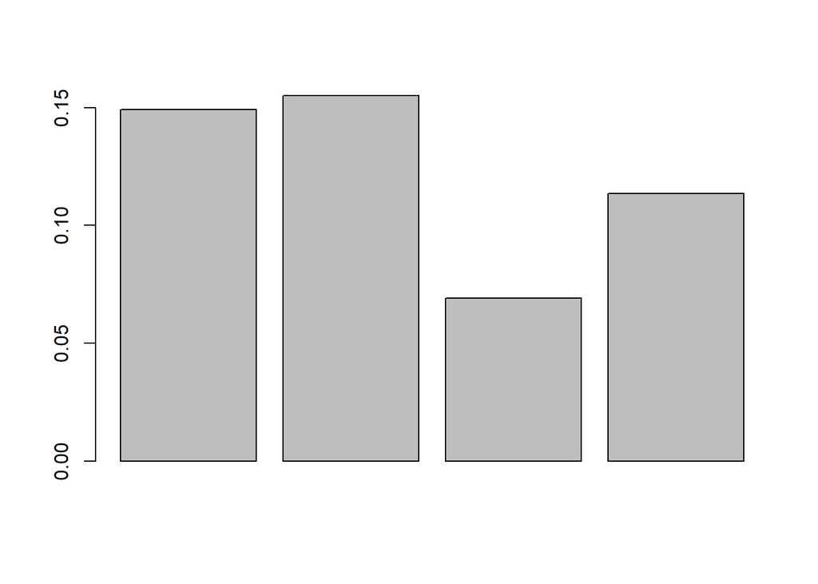

```r
Mapevalue_part_A <- c(0.1491566)
Mapevalue_part_B <- c(0.1550613)
Mapevalue_part_C <- mean(c(0.07337266,0.06792809,0.06531618,0.06531618,0.07385704))
Mapevalue_part_D <- mean(c(0.110087, 0.1044119, 0.1900637, .08253997, 0.079887))
Data_r = c(Mapevalue_part_A, Mapevalue_part_B, Mapevalue_part_C, Mapevalue_part_D)

barplot(Data_r)
```

# SUMMARY

As seen in the bar plot the error rates are better in the model stated in part c